# Multi-classification using Decision Trees

Multi-classification is a common task in machine learning, where we need to classify an instance into one of several possible classes. Decision trees are a popular method for solving multi-classification problems, thanks to their simplicity, interpretability, and ability to handle both numerical and categorical data.

In this exercise, we will be using the built-in sklearn [wine dataset](https://scikit-learn.org/stable/modules/generated/sklearn.datasets.load_wine.html#sklearn.datasets.load_wine). This dataset is commonly used for classification tasks, particularly for multi-class classification using decision trees, logistic regression, and support vector machines.

The load_wine dataset in scikit-learn is a standard machine learning dataset that contains the results of a chemical analysis of wines grown in the same region in Italy, but derived from three different cultivars. The dataset includes 178 wine samples, each with 13 chemical measurements, as well as a target variable indicating the cultivar (i.e., class) of each wine.

The 13 features (i.e., chemical measurements) in the dataset are:

- `Alcohol`: the percentage of alcohol present in each wine sample
- `Malic acid`: the amount of malic acid present in each wine sample
- `Ash`: the amount of ash present in each wine sample
- `Alcalinity` of ash: the level of alcalinity of ash present in each wine sample
- `Magnesium`: the amount of magnesium present in each wine sample
- `Total phenols`: the total amount of phenols present in each wine sample
- `Flavanoids`: the total amount of flavanoids present in each wine sample
- `Nonflavanoid` phenols: the total amount of nonflavanoid phenols present in each wine sample
- `Proanthocyanins`: the total amount of proanthocyanins present in each wine sample
- `Color intensity`: the color intensity of each wine sample
- `Hue`: the hue (i.e., shade) of each wine sample
- `OD280/OD315 of diluted wines`: the ratio of OD280 to OD315 of each wine sample
- `Proline`: the amount of proline present in each wine sample

The target variable is a categorical variable indicating the cultivar (i.e., class) of each wine sample, with three possible values:

- Class 0: Wines produced from the first cultivar
- Class 1: Wines produced from the second cultivar
- Class 2: Wines produced from the third cultivar

```python
# Import relevant libraries
import pandas as pd
import numpy as np
import matplotlib.pyplot as plt

from sklearn.datasets import load_wine
from sklearn.tree import DecisionTreeClassifier, plot_tree
from sklearn.model_selection import train_test_split, cross_val_score, cross_validate
from sklearn.metrics import make_scorer, accuracy_score, precision_score, recall_score, f1_score, confusion_matrix, roc_curve, auc
```

## Prepare Data

```python
# Load the Wine Quality dataset
wine = load_wine(as_frame=True).frame
```

```python
# Separate the features and the target variable
X = wine.drop(['target'], axis=1)
y = wine['target']
```

```python
# Split the dataset into training and testing sets
X_train, X_test, y_train, y_test = train_test_split(X, y, test_size=0.2, random_state=0)
```

## Fit Model

```python
# Create the decision tree classifier object and fit it to the training data
dtc = DecisionTreeClassifier()
```

```python
# Train the decision tree classifier on the training set
dtc.fit(X_train, y_train)
```

```
DecisionTreeClassifier()
```

## Make Predictions

```python
# Predict the classes of the testing data using the trained classifier
y_pred = dtc.predict(X_test)
```

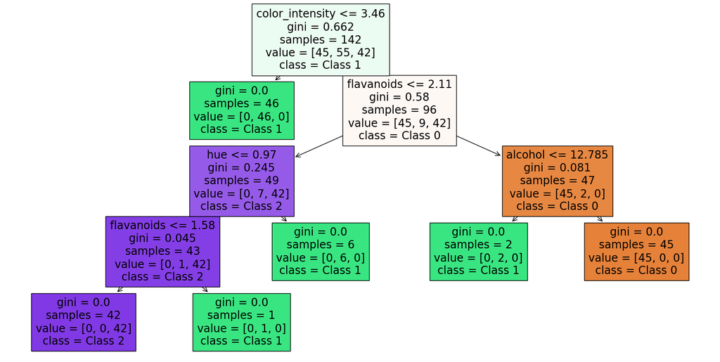

```python
# Plot the decision tree
plt.figure(figsize=(20,10))
plot_tree(dtc, filled=True, feature_names=X.columns, class_names=["Class 0", "Class 1", "Class 2"])
plt.show()
```

## Evaluation Metrics

- Accuracy - Proportion of correctly classified instances out of the total number of instances. Useful to evaluate overall model performance.
- Precision - Proportion of true positive predictions among all positive predictions. Useful to evaluate the accuracy of the positive predictions.
- Recall - Proportion of true positive predictions among all actual positive instances. Useful to evaluate the sensitivity of the model in identifying positive instances.
- F1-score - Harmonic mean of precision and recall. Useful to evaluate the balance between precision and recall.
- Confusion Matrix - A table that shows the true and predicted class labels. Useful to visualize the types of errors made by the model.

```python
# Define the evaluation metrics
scoring = {'accuracy': make_scorer(accuracy_score),
           'precision': make_scorer(precision_score, average='weighted'),
           'recall': make_scorer(recall_score, average='weighted'),
           'f1_score': make_scorer(f1_score, average='weighted')}

# Perform cross-validation
cv_results = cross_validate(dtc, X, y, cv=5, scoring=scoring)

# Print the results
print("Cross-validation results:")
print("Accuracy: ", cv_results['test_accuracy'].mean())
print("Precision: ", cv_results['test_precision'].mean())
print("Recall: ", cv_results['test_recall'].mean())
print("F1-score: ", cv_results['test_f1_score'].mean())
```

```
Cross-validation results:
Accuracy:  0.8765079365079365
Precision:  0.8940999066293184
Recall:  0.8765079365079365
F1-score:  0.8742776981512348
```

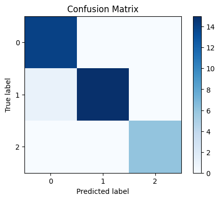

```python
# Plot the confusion matrix
cm = confusion_matrix(y_test, y_pred)
plt.figure(figsize=(6, 4))
plt.imshow(cm, cmap=plt.cm.Blues)
plt.title("Confusion Matrix")
plt.colorbar()
tick_marks = np.arange(len(set(y)))
plt.xticks(tick_marks, set(y))
plt.yticks(tick_marks, set(y))
plt.xlabel('Predicted label')
plt.ylabel('True label')
plt.show()
```

### ROC curve and AUC

The [Receiver Operating Characteristic (ROC) curve](https://en.wikipedia.org/wiki/Receiver_operating_characteristic) is a graphical representation of the performance of a binary classifier as the discrimination threshold is varied. It is created by plotting the True Positive Rate (TPR) against the False Positive Rate (FPR) at various threshold settings.

The ROC curve shows how well the classifier can discriminate between positive and negative instances, and it is particularly useful when the class distribution is imbalanced. A good classifier will have an ROC curve that is closer to the top-left corner of the plot, which corresponds to a high TPR and a low FPR.

The Area Under the ROC Curve (AUC) is a scalar value that represents the overall performance of a binary classifier, independent of the threshold setting. The AUC is equal to the probability that a randomly chosen positive instance is ranked higher than a randomly chosen negative instance by the classifier. An AUC of 1.0 indicates a perfect classifier, while an AUC of 0.5 indicates a random classifier. An AUC between 0.5 and 1.0 indicates a better than random classifier. The AUC is useful for comparing the performance of different classifiers, especially when the class distribution is imbalanced or when the cost of false positives and false negatives is different.

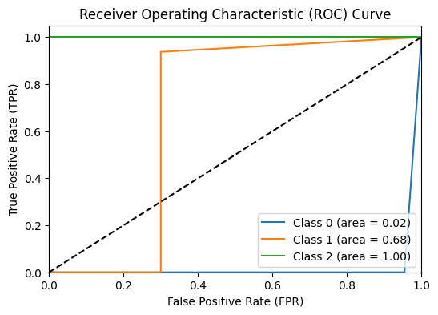

```python
# Plot the ROC curve and calculate the AUC
fpr = dict()
tpr = dict()
roc_auc = dict()
for i in range(len(set(y))):
    fpr[i], tpr[i], _ = roc_curve(y_test, y_pred, pos_label=i)
    roc_auc[i] = auc(fpr[i], tpr[i])

plt.figure(figsize=(6, 4))
for i in range(len(set(y))):
    plt.plot(fpr[i], tpr[i], label='Class {0} (area = {1:0.2f})'.format(i, roc_auc[i]))

plt.plot([0, 1], [0, 1], 'k--')
plt.xlim([0, 1])
plt.ylim([0, 1.05])
plt.xlabel('False Positive Rate (FPR)')
plt.ylabel('True Positive Rate (TPR)')
plt.title('Receiver Operating Characteristic (ROC) Curve')
plt.legend(loc="lower right")
plt.show()
```

To improve the model, we can consider optimizing hyperparameters (max depth of tree, min samples to split node, min samples required at leaf node), feature selection, ensemble methods (random forest, boosting can improve model's accuracy and reduce overfitting), or apply regularization techniques.